# Niklas & Enquist Biomass Database — Detailed Summary

plant_scaling_data project

2026-05-01

# 1 Overview

The **Niklas & Enquist biomass dataset** is a cross-species compilation of plant biomass, height, age, and growth-rate measurements drawn from the primary literature, originally assembled by Enquist and Niklas as the empirical backbone for their metabolic scaling theory papers published in *Nature* and related journals (2001–2004). The primary published data compilation is described in:

> Niklas KJ & Enquist BJ (2001). Invariant scaling relationships for interspecific plant biomass production rates and body size. *PNAS*, 98(5): 2922–2927. DOI: 10.1073/pnas.041590298

> Enquist BJ & Niklas KJ (2002). Global allocation rules for patterns of biomass partitioning in seed plants. *Science*, 295: 1517–1520. DOI: 10.1126/science.1066360

The source CSV (`niklas_enquist_biomass_20040122.csv`) was compiled January 2004 and sourced from Cannell (1982) and other primary literature. Missing values are encoded as −999 in the original file and have been recoded to NA here.

> **⚠ Citation note:** The citations above should be independently verified before use in any manuscript. DOIs have not been checked against Crossref in this exploratory summary.

```r
n_rows  <- nrow(dat)
n_taxa  <- length(unique(dat$taxa))
n_cites <- length(unique(dat$citation))

kable(data.frame(
  Metric  = c("Total records", "Unique taxa strings", "Unique citations"),
  Value   = format(c(n_rows, n_taxa, n_cites), big.mark = ",")
), caption = "Top-level database summary")
```

Top-level database summary

| Metric | Value |
| --- | --- |
| Total records | 2,626 |
| Unique taxa strings | 390 |
| Unique citations | 360 |

# 2 Data structure

## 2.1 Column dictionary

```r
col_dict <- data.frame(
  Column            = c("taxa","citation","footnotes","record_num",
                        "age_yr","height_m",
                        "root_biomass_kg","stem_biomass_kg","leaf_biomass_kg",
                        "shoot_biomass_kg","repro_biomass_kg","total_biomass_kg",
                        "stem_growth_kgyr","leaf_growth_kgyr",
                        "root_growth_kgyr","total_growth_kgyr"),
  Unit              = c("—","—","—","—",
                        "yr","m",
                        "kg dry wt","kg dry wt","kg dry wt",
                        "kg dry wt","kg dry wt","kg dry wt",
                        "kg yr⁻¹","kg yr⁻¹","kg yr⁻¹","kg yr⁻¹"),
  Description       = c("Taxon name (may include mixed stands)",
                        "Literature citation string",
                        "Footnotes from Cannell (1982) pages",
                        "Original sort order from source table",
                        "Plant age","Plant height",
                        "Root dry biomass per plant",
                        "Stem dry biomass per plant",
                        "Leaf dry biomass per plant",
                        "Shoot (stem+leaf) dry biomass per plant",
                        "Reproductive organ dry biomass",
                        "Total dry biomass (root+stem+leaf)",
                        "Annual stem dry mass increment",
                        "Annual leaf dry mass increment",
                        "Annual root dry mass increment",
                        "Annual total dry mass increment")
)
kable(col_dict, caption = "Column dictionary for Niklas-Enquist dataset")
```

Column dictionary for Niklas-Enquist dataset

| Column | Unit | Description |
| --- | --- | --- |
| taxa | — | Taxon name (may include mixed stands) |
| citation | — | Literature citation string |
| footnotes | — | Footnotes from Cannell (1982) pages |
| record_num | — | Original sort order from source table |
| age_yr | yr | Plant age |
| height_m | m | Plant height |
| root_biomass_kg | kg dry wt | Root dry biomass per plant |
| stem_biomass_kg | kg dry wt | Stem dry biomass per plant |
| leaf_biomass_kg | kg dry wt | Leaf dry biomass per plant |
| shoot_biomass_kg | kg dry wt | Shoot (stem+leaf) dry biomass per plant |
| repro_biomass_kg | kg dry wt | Reproductive organ dry biomass |
| total_biomass_kg | kg dry wt | Total dry biomass (root+stem+leaf) |
| stem_growth_kgyr | kg yr⁻¹ | Annual stem dry mass increment |
| leaf_growth_kgyr | kg yr⁻¹ | Annual leaf dry mass increment |
| root_growth_kgyr | kg yr⁻¹ | Annual root dry mass increment |
| total_growth_kgyr | kg yr⁻¹ | Annual total dry mass increment |

## 2.2 Data availability per column

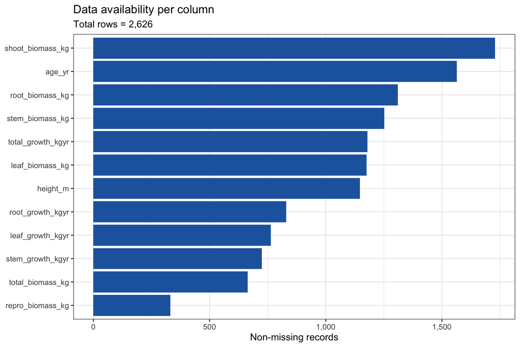

```r
num_cols <- c("age_yr","height_m","root_biomass_kg","stem_biomass_kg",
              "leaf_biomass_kg","shoot_biomass_kg","repro_biomass_kg",
              "total_biomass_kg","stem_growth_kgyr","leaf_growth_kgyr",
              "root_growth_kgyr","total_growth_kgyr")

avail <- dat |>
  summarise(across(all_of(num_cols), ~ sum(!is.na(.)))) |>
  pivot_longer(everything(), names_to = "variable", values_to = "n") |>
  arrange(desc(n))

ggplot(avail, aes(x = reorder(variable, n), y = n)) +
  geom_col(fill = "#2166ac") +
  coord_flip() +
  scale_y_continuous(labels = comma) +
  labs(x = NULL, y = "Non-missing records",
       title = "Data availability per column",
       subtitle = paste0("Total rows = ", format(n_rows, big.mark = ",")))
```

```r
rng <- dat |>
  summarise(across(all_of(num_cols),
    list(n = ~ sum(!is.na(.)),
         min = ~ round(min(., na.rm = TRUE), 4),
         max = ~ round(max(., na.rm = TRUE), 2)),
    .names = "{.col}__{.fn}")) |>
  pivot_longer(everything(),
    names_to = c("variable", "stat"), names_sep = "__") |>
  pivot_wider(names_from = stat, values_from = value)

kable(rng, caption = "Non-missing counts and value ranges for numeric columns")
```

Non-missing counts and value ranges for numeric columns

| variable | n | min | max |
| --- | --- | --- | --- |
| age_yr | 1564 | 0.0000 | 372.50 |
| height_m | 1147 | 0.0093 | 49.90 |
| root_biomass_kg | 1310 | 0.0000 | 1818.70 |
| stem_biomass_kg | 1252 | 0.0000 | 2686.49 |
| leaf_biomass_kg | 1175 | 0.0000 | 128.51 |
| shoot_biomass_kg | 1729 | 0.0000 | 6865.10 |
| repro_biomass_kg | 331 | 0.0000 | 55.45 |
| total_biomass_kg | 664 | 0.0000 | 3183.78 |
| stem_growth_kgyr | 725 | 0.0000 | 93.09 |
| leaf_growth_kgyr | 764 | 0.0000 | 35.68 |
| root_growth_kgyr | 830 | 0.0000 | 17.97 |
| total_growth_kgyr | 1180 | 0.0000 | 123.04 |

# 3 Taxonomic coverage

## 3.1 Top taxa by record count

```r
taxa_counts <- dat |>
  filter(!is.na(taxa)) |>
  count(taxa, sort = TRUE)

kable(head(taxa_counts, 50),
      col.names = c("Taxon string", "N records"),
      caption = "Top 50 taxa by record count (note: includes mixed stands and crop species)")
```

Top 50 taxa by record count (note: includes mixed stands and crop species)

| Taxon string | N records |
| --- | --- |
| pearl millit | 360 |
| Cryptomeria japonica | 119 |
| Triticum aestivum | 86 |
| Pisum sativum | 54 |
| Populus | 51 |
| capsella | 51 |
| Chamaecyparis obtusa | 50 |
| Dolicus | 50 |
| Soja max | 44 |
| Cucumber | 42 |
| Picea mariana | 37 |
| Betula pendula | 36 |
| Pinus sylvestris | 33 |
| Fagus sylvatica | 26 |
| Picea abies | 26 |
| Cotton | 24 |
| Pinus banksiana | 24 |
| Vicia faba | 24 |
| P. peltatum | 23 |
| Acacia mangium | 22 |
| A. Sativa | 20 |
| Abies alba | 19 |
| Barley | 19 |
| Fagus crenata with a few Quercus mongolica, Magnolia obovata, Kalopanax septemlobus et al. | 19 |
| Pinus rigida | 19 |
| Oenothera biennis | 18 |
| Elaeis guineensis (oil palm) | 17 |
| Hevea braziliensis | 17 |
| Pinus thunbergii | 17 |
| Populus tremuloides | 17 |
| Vaccinium vilis-idaea | 17 |
| Betula papyrifera | 16 |
| Empetrum hemaphrodium | 16 |
| Pinus densiflora | 16 |
| Pinus radiata | 16 |
| Alliaria petiolata | 15 |
| Taraxiucm officinale | 15 |
| Vaccinium uliginosum | 15 |
| Castanopsis cuspidata | 14 |
| Cyperus rotundus | 14 |
| Deschampsia flexuosa | 14 |
| Abies veitchii | 13 |
| Micranda spruceana, Eperua leucantha and about 130 other species. | 13 |
| Pinus sylvestria | 13 |
| Avena sativa | 12 |
| Bromus calharicus | 12 |
| Maize | 12 |
| Pinus banksiana, with some Picea mariana et al. | 12 |
| Pinus nigra var. maritima | 12 |
| Pinus sylvestris with Picea abies et al. | 12 |

## 3.2 Taxa string composition

The dataset spans vascular plants including wild woody species, crops, and annual herbs. Taxon strings are free-text from the original publications and have not been harmonized to a taxonomic backbone in this exploratory summary.

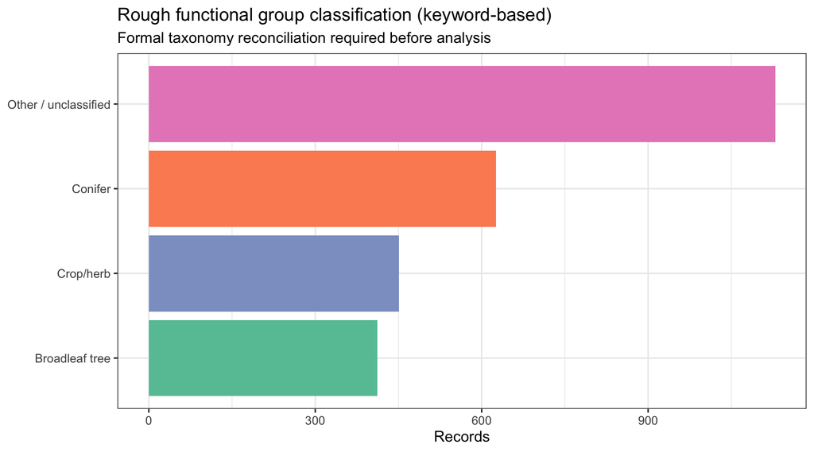

```r
# Rough classification by keywords
dat2 <- dat |>
  filter(!is.na(taxa)) |>
  mutate(likely_type = case_when(
    str_detect(taxa, regex("Pinus|Picea|Abies|Larix|Tsuga|Pseudotsuga|Cryptomeria|Chamaecyparis|Cedrus|Taxus", ignore_case=TRUE)) ~ "Conifer",
    str_detect(taxa, regex("wheat|barley|maize|corn|rice|soya|soybean|pea|bean|millet|oat|rye|cotton|sunflower|tobacco|potato", ignore_case=TRUE)) ~ "Crop/herb",
    str_detect(taxa, regex("Quercus|Fagus|Betula|Populus|Acer|Fraxinus|Alnus|Eucalyptus|Acacia", ignore_case=TRUE)) ~ "Broadleaf tree",
    TRUE ~ "Other / unclassified"
  ))

dat2 |>
  count(likely_type, sort = TRUE) |>
  ggplot(aes(x = reorder(likely_type, n), y = n, fill = likely_type)) +
  geom_col(show.legend = FALSE) +
  coord_flip() +
  scale_y_continuous(labels = comma) +
  scale_fill_brewer(palette = "Set2") +
  labs(x = NULL, y = "Records",
       title = "Rough functional group classification (keyword-based)",
       subtitle = "Formal taxonomy reconciliation required before analysis")
```

# 4 Geographic coverage

> **⚠ Caveat:** The Niklas-Enquist CSV contains **no latitude/longitude columns**. Geographic origin is inferred here by keyword-matching citation strings and, secondarily, taxon names. Assignments are approximate and unverified. Centroids represent the broad inferred region, not precise sampling locations.

```r
# ── Keyword → region lookup ───────────────────────────────────────────────────
# Rules are ordered: first match wins. More-specific rules precede catch-alls.
classify_region <- function(citation, taxa) {
  cit <- ifelse(is.na(citation), "", citation)
  tax <- ifelse(is.na(taxa), "", taxa)

  dplyr::case_when(
    # Sudan
    grepl("Gezira",           cit, ignore.case=TRUE) ~ "Sudan",

    # Germany
    grepl("Harz Mountains|Germany|Gentianella Germanica", cit, ignore.case=TRUE) ~ "Germany",

    # Sweden / Scandinavia
    grepl("Sweden|Swedish|J.derlund|Jaderlund|Zackrisson|Norberg", cit, ignore.case=TRUE) ~ "Sweden",

    # Finland
    grepl("Finland|Finnish|Oksanen", cit, ignore.case=TRUE) ~ "Finland",

    # Pakistan
    grepl("Pakistan Journal", cit, ignore.case=TRUE) ~ "Pakistan",

    # India
    grepl("India|Indian Forestry", cit, ignore.case=TRUE) |
      grepl("Inamdar|Kharak Singh", cit, ignore.case=TRUE) ~ "India",

    # French Guiana
    grepl("French Guiana", cit, ignore.case=TRUE) ~ "French Guiana",

    # Sri Lanka
    grepl("Gunatilleke|Sri Lanka|Peradeniya", cit, ignore.case=TRUE) ~ "Sri Lanka",

    # Alaska (explicitly named)
    grepl("Alaskan|Alaska", cit, ignore.case=TRUE) ~ "Alaska (USA)",

    # USA (explicit state/institution clues)
    grepl("Georgia, U\\.S\\.A|Cornell University|Ithaca, New York|loblolly|slash pine",
          cit, ignore.case=TRUE) ~ "USA",
    grepl("Douglas-fir seedlings|Pacific Northwest|Michigan|Ohio|Minnesota|Populus tremuloides.*sucoff",
          cit, ignore.case=TRUE) ~ "USA",

    # Australia
    grepl("Australia|Snowy Mountains|Eucalypt", cit, ignore.case=TRUE) ~ "Australia",

    # UK / British Isles (Scotland explicitly)
    grepl("Scotland|Blanket Peat.*Scotland", cit, ignore.case=TRUE) ~ "Scotland (UK)",
    grepl("British Isles|Journal of Ecology|Annals of Bot|Biological Flora|Heather Moorland",
          cit, ignore.case=TRUE) ~ "UK / Europe",

    # Canada (Can. J. For. Res. studies that describe Canadian work)
    grepl("Can\\. J\\. For\\. Res\\.|Canadian Journal",
          cit, ignore.case=TRUE) ~ "Canada / North America",

    # Cannell compilation — global multi-region
    grepl("Cannell", cit, ignore.case=TRUE) ~ "Global (Cannell 1982)",

    # Unpublished / personal communication
    grepl("personal communication|unpublished data", cit, ignore.case=TRUE) ~ "USA (unpublished)",

    TRUE ~ "Unclassified"
  )
}

dat_geo <- dat |>
  mutate(region = classify_region(citation, taxa))
```

[figure not shown]

```r
library(maps)

# Approximate centroids (longitude, latitude) for each region
centroids <- data.frame(
  region = c("UK / Europe","Scotland (UK)","Germany","Sweden","Finland",
             "Canada / North America","USA","Alaska (USA)",
             "Australia","French Guiana","India","Pakistan","Sri Lanka","Sudan",
             "Global (Cannell 1982)","USA (unpublished)","Unclassified"),
  lon = c(-2, -4, 10, 18, 25,
          -96, -98, -153,
          134, -53, 78, 67, 81, 32,
          0, -80, 0),
  lat = c(52, 57, 51, 62, 64,
          56, 40, 64,
          -25, 4, 22, 30, 8, 15,
          20, 38, 0),
  stringsAsFactors = FALSE
)

region_counts <- dat_geo |>
  count(region, sort = TRUE)

plot_df <- region_counts |>
  left_join(centroids, by = "region") |>
  filter(!is.na(lon))

world_map <- map_data("world")

ggplot() +
  geom_polygon(data = world_map,
               aes(x = long, y = lat, group = group),
               fill = "grey88", color = "grey70", linewidth = 0.2) +
  geom_point(data = plot_df,
             aes(x = lon, y = lat, size = n, color = region),
             alpha = 0.75) +
  geom_text(data = plot_df,
            aes(x = lon, y = lat, label = n),
            size = 3, vjust = -1.3, fontface = "bold") +
  scale_size_continuous(range = c(3, 18), guide = "none") +
  coord_fixed(1.3, xlim = c(-170, 165), ylim = c(-55, 75)) +
  scale_color_brewer(palette = "Paired") +
  labs(
    title = "Niklas-Enquist dataset — inferred geographic origin of observations",
    subtitle = paste0("⚠ No lat/lon in source file. Regions keyword-inferred from citation text (n = ",
                      format(nrow(dat_geo), big.mark=","), " records)"),
    color = "Inferred region",
    x = NULL, y = NULL
  ) +
  theme(legend.position = "right",
        axis.text = element_blank(),
        axis.ticks = element_blank(),
        panel.grid = element_blank())
```

[figure not shown]

```r
region_counts |>
  filter(region != "Unclassified") |>
  ggplot(aes(x = reorder(region, n), y = n, fill = region)) +
  geom_col(show.legend = FALSE) +
  geom_text(aes(label = n), hjust = -0.2, size = 3.5) +
  coord_flip() +
  scale_y_continuous(labels = comma, expand = expansion(mult = c(0, 0.15))) +
  scale_fill_brewer(palette = "Paired") +
  labs(x = NULL, y = "Records",
       title = "Records per inferred geographic region",
       subtitle = "⚠ Approximate keyword classification only")
```

```r
kable(region_counts,
      col.names = c("Inferred region", "N records"),
      caption = paste0("Record counts by inferred geographic region. ",
                       "Regions are keyword-classified, not verified coordinates. ",
                       "Cannell (1982) is a global compilation of primary literature ",
                       "spanning multiple continents."))
```

Record counts by inferred geographic region. Regions are keyword-classified, not verified coordinates. Cannell (1982) is a global compilation of primary literature spanning multiple continents.

| Inferred region | N records |
| --- | --- |
| Global (Cannell 1982) | 1057 |
| UK / Europe | 647 |
| USA | 564 |
| Canada / North America | 156 |
| India | 95 |
| Finland | 36 |
| Pakistan | 24 |
| Sudan | 14 |
| Australia | 8 |
| Germany | 6 |
| Sri Lanka | 6 |
| Scotland (UK) | 4 |
| Sweden | 4 |
| French Guiana | 3 |
| Alaska (USA) | 1 |
| Unclassified | 1 |

# 5 Age and size distributions

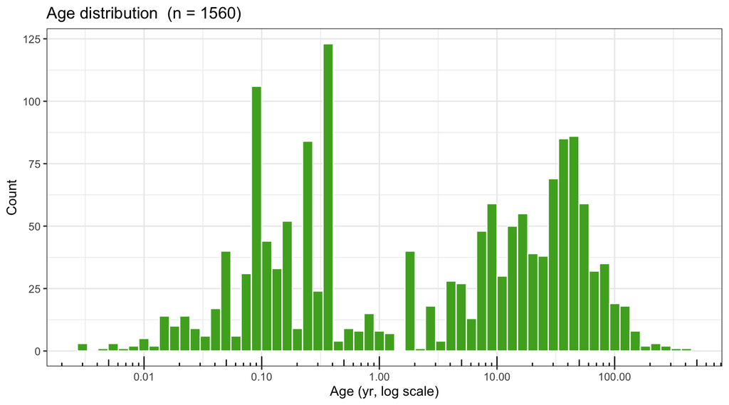

```r
dat |> filter(!is.na(age_yr), age_yr > 0) |>
  ggplot(aes(x = age_yr)) +
  geom_histogram(bins = 60, fill = "#4dac26", color = "white") +
  scale_x_log10(labels = comma) +
  scale_y_continuous(labels = comma) +
  annotation_logticks(sides = "b") +
  labs(x = "Age (yr, log scale)", y = "Count",
       title = paste0("Age distribution  (n = ", sum(!is.na(dat$age_yr) & dat$age_yr > 0), ")"))
```

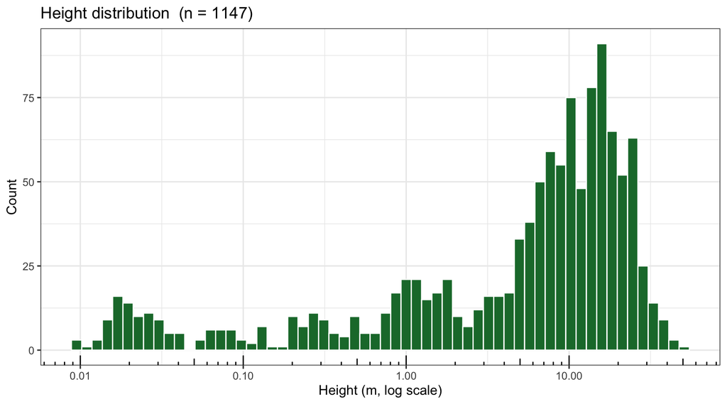

```r
dat |> filter(!is.na(height_m), height_m > 0) |>
  ggplot(aes(x = height_m)) +
  geom_histogram(bins = 60, fill = "#1b7837", color = "white") +
  scale_x_log10(labels = comma) +
  scale_y_continuous(labels = comma) +
  annotation_logticks(sides = "b") +
  labs(x = "Height (m, log scale)", y = "Count",
       title = paste0("Height distribution  (n = ", sum(!is.na(dat$height_m) & dat$height_m > 0), ")"))
```

# 6 Scaling relationships

All biomass variables are in **kg dry weight per plant**. Height is in **m**. Age is in **yr**. All regressions below are **exploratory OLS on log10-transformed data**. Standardized Major Axis (SMA) regression using `smatr` is required for unbiased allometric exponent estimation and will be applied in the formal analysis phase.

## 6.1 Total biomass vs. height

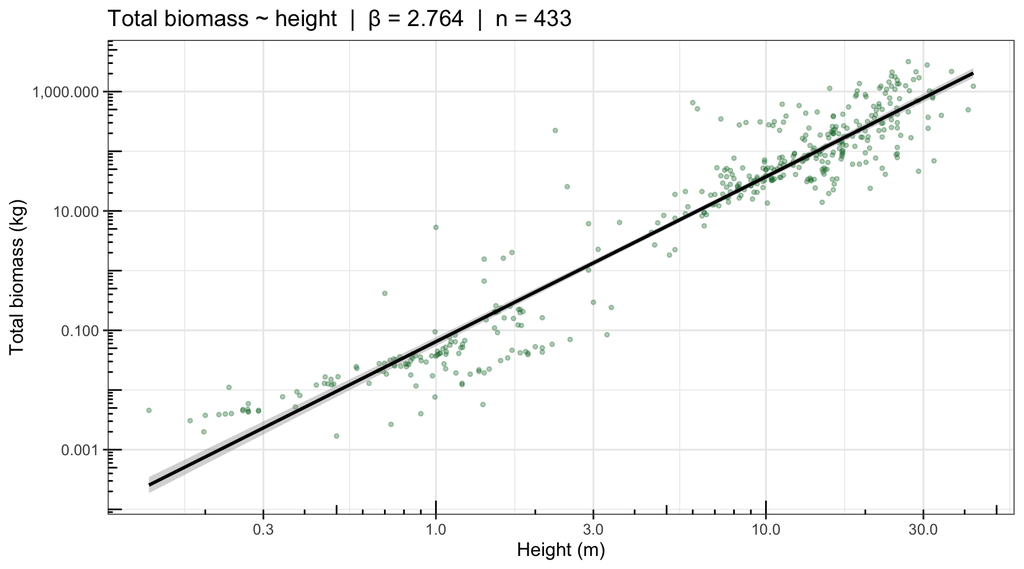

```r
d1 <- dat |> filter(total_biomass_kg > 0, height_m > 0)
lm1 <- lm(log10(total_biomass_kg) ~ log10(height_m), data = d1)
b1 <- round(coef(lm1)[2], 3)
a1 <- round(10^coef(lm1)[1], 4)
n1 <- nrow(d1)

ggplot(d1, aes(x = height_m, y = total_biomass_kg)) +
  geom_point(alpha = 0.35, size = 1, color = "#1b7837") +
  geom_smooth(method = "lm", color = "black", linewidth = 1) +
  scale_x_log10(labels = comma) + scale_y_log10(labels = comma) +
  annotation_logticks() +
  labs(x = "Height (m)", y = "Total biomass (kg)",
       title = paste0("Total biomass ~ height  |  β = ", b1, "  |  n = ", format(n1, big.mark=",")))
```

> OLS: total_biomass = 0.0646 × height^2.764 (n = 433).

## 6.2 Stem biomass vs. total biomass

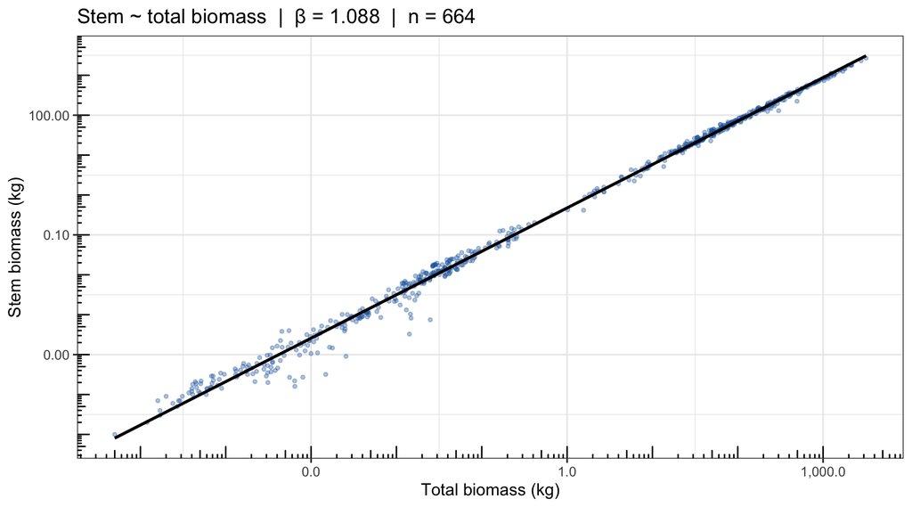

```r
d2 <- dat |> filter(stem_biomass_kg > 0, total_biomass_kg > 0)
lm2 <- lm(log10(stem_biomass_kg) ~ log10(total_biomass_kg), data = d2)
b2 <- round(coef(lm2)[2], 3); n2 <- nrow(d2)

ggplot(d2, aes(x = total_biomass_kg, y = stem_biomass_kg)) +
  geom_point(alpha = 0.35, size = 1, color = "#2166ac") +
  geom_smooth(method = "lm", color = "black", linewidth = 1) +
  scale_x_log10(labels = comma) + scale_y_log10(labels = comma) +
  annotation_logticks() +
  labs(x = "Total biomass (kg)", y = "Stem biomass (kg)",
       title = paste0("Stem ~ total biomass  |  β = ", b2, "  |  n = ", format(n2, big.mark=",")))
```

## 6.3 Leaf biomass vs. total biomass

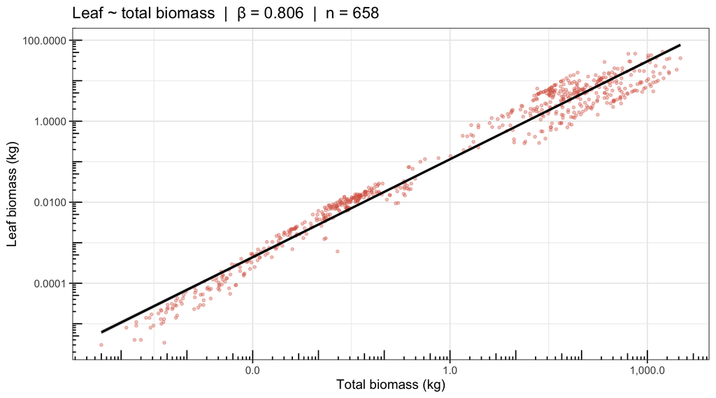

```r
d3 <- dat |> filter(leaf_biomass_kg > 0, total_biomass_kg > 0)
lm3 <- lm(log10(leaf_biomass_kg) ~ log10(total_biomass_kg), data = d3)
b3 <- round(coef(lm3)[2], 3); n3 <- nrow(d3)

ggplot(d3, aes(x = total_biomass_kg, y = leaf_biomass_kg)) +
  geom_point(alpha = 0.35, size = 1, color = "#d6604d") +
  geom_smooth(method = "lm", color = "black", linewidth = 1) +
  scale_x_log10(labels = comma) + scale_y_log10(labels = comma) +
  annotation_logticks() +
  labs(x = "Total biomass (kg)", y = "Leaf biomass (kg)",
       title = paste0("Leaf ~ total biomass  |  β = ", b3, "  |  n = ", format(n3, big.mark=",")))
```

## 6.4 Root biomass vs. total biomass

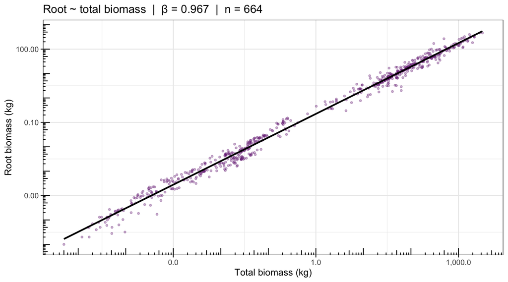

```r
d4 <- dat |> filter(root_biomass_kg > 0, total_biomass_kg > 0)
lm4 <- lm(log10(root_biomass_kg) ~ log10(total_biomass_kg), data = d4)
b4 <- round(coef(lm4)[2], 3); n4 <- nrow(d4)

ggplot(d4, aes(x = total_biomass_kg, y = root_biomass_kg)) +
  geom_point(alpha = 0.35, size = 1, color = "#762a83") +
  geom_smooth(method = "lm", color = "black", linewidth = 1) +
  scale_x_log10(labels = comma) + scale_y_log10(labels = comma) +
  annotation_logticks() +
  labs(x = "Total biomass (kg)", y = "Root biomass (kg)",
       title = paste0("Root ~ total biomass  |  β = ", b4, "  |  n = ", format(n4, big.mark=",")))
```

## 6.5 Total growth rate vs. total biomass

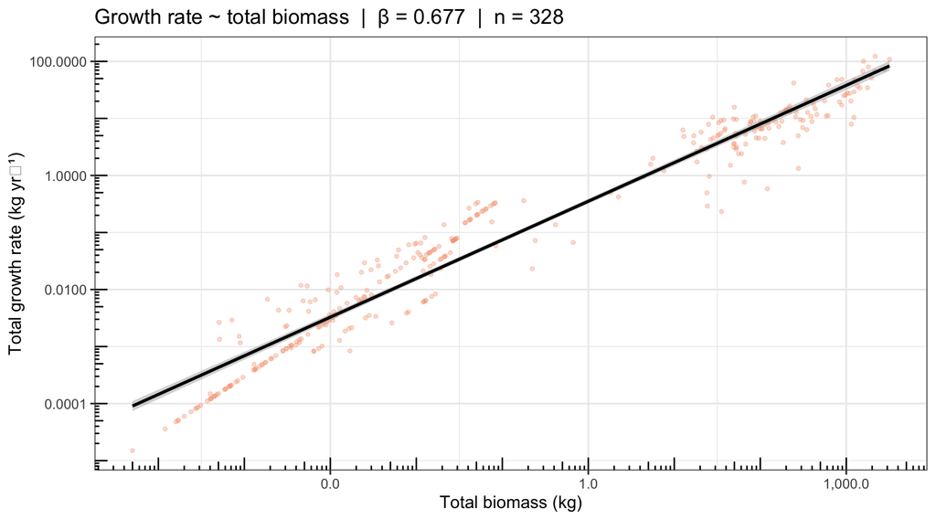

```r
d5 <- dat |> filter(total_growth_kgyr > 0, total_biomass_kg > 0)
lm5 <- lm(log10(total_growth_kgyr) ~ log10(total_biomass_kg), data = d5)
b5 <- round(coef(lm5)[2], 3); n5 <- nrow(d5)

ggplot(d5, aes(x = total_biomass_kg, y = total_growth_kgyr)) +
  geom_point(alpha = 0.35, size = 1, color = "#f4a582") +
  geom_smooth(method = "lm", color = "black", linewidth = 1) +
  scale_x_log10(labels = comma) + scale_y_log10(labels = comma) +
  annotation_logticks() +
  labs(x = "Total biomass (kg)", y = "Total growth rate (kg yr⁻¹)",
       title = paste0("Growth rate ~ total biomass  |  β = ", b5, "  |  n = ", format(n5, big.mark=",")))
```

> The WBE metabolic scaling prediction is β ≈ 0.75 for production ∝ biomass.

## 6.6 Summary of scaling exponents (exploratory OLS)

```r
exponents <- data.frame(
  Relationship      = c("total_biomass ~ height",
                        "stem_biomass ~ total_biomass",
                        "leaf_biomass ~ total_biomass",
                        "root_biomass ~ total_biomass",
                        "total_growth ~ total_biomass"),
  OLS_beta          = c(b1, b2, b3, b4, b5),
  n                 = c(n1, n2, n3, n4, n5)
)
kable(exponents, caption = "Exploratory OLS scaling exponents (log10-log10). Use SMA for formal inference.")
```

Exploratory OLS scaling exponents (log10-log10). Use SMA for formal inference.

| Relationship | OLS_beta | n |
| --- | --- | --- |
| total_biomass ~ height | 2.764 | 433 |
| stem_biomass ~ total_biomass | 1.088 | 664 |
| leaf_biomass ~ total_biomass | 0.806 | 658 |
| root_biomass ~ total_biomass | 0.967 | 664 |
| total_growth ~ total_biomass | 0.677 | 328 |

# 7 Source citations

```r
cites <- dat |>
  filter(!is.na(citation)) |>
  mutate(citation = iconv(citation, to = "UTF-8", sub = "?"),
         citation = substr(citation, 1, 200)) |>
  count(citation, sort = TRUE)

kable(cites, col.names = c("Citation string", "N records"), escape = TRUE,
      caption = paste0("All ", nrow(cites), " source citation strings in the dataset"))
```

All 359 source citation strings in the dataset

| Citation string | N records |
| --- | --- |
| Karl J. Niklas, unpublished data, Cornell University, Ithaca, New York, 2003. | 512 |
| Interaction of Irradiance and Soil Nutrient Supply on Growth of Seedlings of Ten European Tall-Shrub Species and Fagus Sylvatica. Peter J. Grubb, William G. Lee, Johannes Kollmann, J. Bastow Wilson. | 72 |
| Development of Root System of Wheat in Different Kinds of Soils with Different Methods of Watering. Kharak Singh. Annals of Botany, Vol 36 No 143 (July 1922) Pp 353-360. | 66 |
| Growth Responses of Four Sub-Arctic Dwarf Shrubs to Simulated Environmental Change. A. N. Parsons, J. M. Welker, P. A. Wookey, M. C. Press, T. V. Callaghan, J. A. Lee. Journal of Ecology, Vol. 82, N | 56 |
| Studies in Growth IV. Correlations in Development. W.H. Pearsall. Annals of Botany, Vol 37 No. 146 (April 1923). Pp. (261-275). | 49 |
| Influence of Ammonium Sulfate on Plant Growth in Nutrient Solutions and its Effect on Hydrogen ion Concentration and Iron Availability. Linus H. Jones and John W. Shive. Annals of Botany, Vol 37 No | 44 |
| Studies in the Energy Relations of Plants II. The Effect of Temperature on Increase in Area of Leaf Surface and in Dry Weight of Cucumis sativus. F.G. Gregory. Annals of Botany. Vol 42, No 166 (Ap | 42 |
| Succession from Heather Moorland to Birch Woodland. III. A. J. Hester, C. H. Gimingham, J. Miles. Journal of Ecology, Vol. 79, No. 2. (Jun., 1991), pp. 329-344. | 40 |
| Differences of Betula origins in ozone sensitivity based on open-field experiment over two growing seasons. Elina Oksanen and Matti Rousi. Can. J. For. Res. 31: 804-811. | 36 |
| Variation in response to nutrition in a three-generation pedigree of Populus. S. Abdul Karim and B.J. Hawkins. Can. J. For. Res. 29: 1743-1750. | 31 |
| Biomass partitioning and nitrogen retranslocation in black spruce seedlings on competitive mixedwood sites: a bioassay study. V. Malik and V.R. Timmer. Can. J. For. Res. 28: 206-215. | 30 |
| The Growth of the Cotton Plant in India. R.S. Inamdar, S.B. Singh, and T.D. Pande. Annals of Botany, Vol 39, No 154 (April 1925). Pp 281-311. | 28 |
| The Plant Ecology of Serpentine II. Plant Response to Serpentine Soils. John Proctor. Journal of Ecology, Vol 59, No 2 (July 1971) Pp 397-410. | 22 |
| The requirement of iron for nodulation and growth of (Acacia mangium). D. Lesueur and H.G. Diem. Can. J. For. Res. 27: 686-692. | 22 |
| Growth of five hybrid poplar genotypes exposed to interacting elevated CO2 and O3. R.E. Dickson, M.D. Coleman, D.E. Riemenschneider, J.G. Isebrands, G.D. Hogan, and D.F. Karnosky. Can. J. For. Res. | 20 |
| Interactive Effects of (2-Chloroethyl)-Trimethyllammonium Chloride and Phytohormones on growth of wheat seedlings. F. Begum and M.I. Khan. Pakistan Journal of Botany, Vol 4, No. 1. (June 1972) Pp: 3 | 20 |
| The role of Boron in the Growth of Plants. Winifred E. Brenchley and Katherine Warington. Annals of Botoany, Vol 41, No. 161 (January 1927). Pp. 167-187. | 20 |
| Can comparative approaches predict the nature of biotic interactions and individual plant species effects in ecosystems? D.A. Wardle, G.M. Barker, K.I. Bonner, K.S. Nicholson. Journal of Ecology, Vol | 19 |
| The Phosphate Requirement of Barely at Different Periods of Growth. Winifred E. Brenchley. Annals of Botany, Vol. 43, No 169 (January 1929). Pp. 89-109. | 19 |
| The Effect of Reproduction on Canopy Structure, Allocation and Growth in Oenothera Biennis. E. G. Reekie, J. Y. C. Reekie. Journal of Ecology, Vol. 79, No. 4. (Dec., 1991), pp. 1061-1071. | 18 |
| Herbivores and the Performance of Grassland Plants: A Comparison of Arthropod, Mollusc and Rodent Herbivory. Philip E. Hulme. Journal of Ecology, Vol. 84, No. 1. (Feb., 1996), pp. 43-51. | 16 |
| High Benefits of Clonal Integration in Two Stoloniferous Species, in Response to Heterogeneous Light Environments. Josef F. Stuefer, Heinjo J. During, Hans de Kroon. Journal of Ecology, Vol. 82, No. | 16 |
| Relative growth rate and biomass allocation of paper birch (Betula papyrifera) populations under different soil moisture and nutrient regimes. Jian R. Wang, C.D.B. Hawkins, and Tony Letchford. Can. | 16 |
| Response of Seeds and Seedlings to Treatment with Indolylacetic Acid. Y. Hwang and H.L. Pearse. Annals of Botany, N.S. Vol 4, No 13 (January 1940) Pp. 31-37. | 16 |
| Christopher Hogan, personal communication of unpublished data to Karl J. Niklas, Cornell University, Ithaca, New York, 2003. (Student of K. Niklas) | 15 |
| Responses of the biennial forest herb Alliaria petiolata to variation in population density, nutrient addition and light availability. J. Forrest Meekins; Brian C. McCarthy. Journal of Ecology, Vol. | 15 |
| The response of Plants in Soil and in Water Culture to Aeration of the Roots. R.C. Knight. Annals of Botany, Vol 38, No 150 (April 1924) Pp. 305-325. | 15 |
| A study of Nut Grass (Cyperus Rotundus L.) in the Cotton Soil of the Gezira. F.W. Andrews. Annals of Botany, N.S. Vol 4, No. 13 (January 1940) Pp (177-193). | 14 |
| Cannell (1982). Page 272 | 12 |
| Effects of the Systemic Flower Infecting-Smut Ustilago Bullata on the Growth and Competitive Ability of the Grass Bromus Catharticus. Graciela Garcia-Guzman, J. J. Burdon, A. O. Nicholls. Journal of | 12 |

[output cut: 329 more lines]

# 8 Key caveats

1. **Taxon strings are unharmonized.** Many entries are free-text names from Cannell (1982) and include mixed-stand descriptions, common names, and synonyms. Taxonomy reconciliation against a backbone (TPL, TNRS, or GBIF) is required before cross-dataset merging.
2. **Missing data sentinel.** The original file uses −999 for missing values. These have been recoded to NA here; downstream scripts must not treat −999 as a valid observation.
3. **Crops and annuals.** The dataset includes crop species (pearl millet, wheat, pea, soybean) alongside forest trees. Analyses of interspecific woody-plant scaling should filter on functional group or growth form.
4. **Shoot vs. total biomass.** `shoot_biomass_kg` = stem + leaf (above-ground except reproduction). `total_biomass_kg` = root + stem + leaf. These must not be used interchangeably.
5. **Log columns.** Pre-computed log10 columns are present in the source file but are derived quantities. The raw biomass columns should be used for independent analysis.
6. **OLS bias.** All exponents reported here are OLS on log-transformed data. These underestimate true allometric exponents when both axes have error. Use SMA (`smatr::sma()`) for publication-quality inference.
7. **Citation verification required.** The Niklas & Enquist (2001) and Enquist & Niklas (2002) references listed in the Overview need independent DOI and metadata verification before inclusion in any methods narrative.